# Data wrangling for sensor outputs

***Note:** I have enabled warnings so as to double check the result and is expected, refer README.md for more details on warnings.

**Just for quick visualisation of variables**

Use it to debug and for quick visualisation set *eval:false* unless you want to render it (further data cleaning can be employed if necessary (for ex: dealing with outliers))

**Loading required packages**

```r
#|warning: true
#|message: true
#|eval: true
library(tidyverse)
library(fs)
library(reticulate) #Library used to embed python code if required
```

**Choosing the date of experiment**

```r
#|message: true
#|eval: true
#|warning: true

#Below enter the date of the data
enter_Date <- "22-02-24"
folder_Path <- paste0("data/", enter_Date)
```

**Reading all the sensor logs**

```r
#|message: true
#|eval: true
#|warning: true

#Takes in temp, humidity & flow log as text and replaces every unprintable character with ""
file_content_1 <- readLines(dir_ls(folder_Path, regexp = "Flow")) %>%
  str_replace_all("[^[:print:]]", "")
#Takes in temp reading (from PID)
file_content_2 <- readLines(dir_ls(folder_Path, regexp = "Regelung")) %>%
  str_replace_all("[^[:print:]]", "")

#Takes in vaisala_in sensor log
file_content_3 <- readLines(dir_ls(folder_Path, regexp = "In")) %>%
  str_replace_all("[^[:print:]]", "")
 #Takes in vaisala_out sensor log
file_content_4 <- readLines(dir_ls(folder_Path, regexp = "Out")) %>%
  str_replace_all("[^[:print:]]", "")
```

**Log from temperature, humidity and flow sensor**

```r
#|message : false
#|eval: true
#|warning: false

line_filter_1 <- grep("^\\s*temp\\(C\\):\\d+\\.\\d+ humidity\\(%\\):\\d+\\.\\d+ flow\\(L/m\\):\\d+$",
                      file_content_1,
                      value = TRUE)

file_content_1_data <- line_filter_1 %>%
  str_extract_all("temp\\(C\\):\\d+\\.\\d+|humidity\\(%\\):\\d+\\.\\d+|flow\\(L/m\\):\\d+") %>%
   map(~str_extract_all(., "\\d+\\.\\d+|\\d+") %>%
        unlist() %>%
        as.numeric())

sensor_1_df <- do.call(rbind, file_content_1_data) %>%
  as.data.frame() %>%
  setNames(c("temperature(C)", "humidity(%)", "flow(L\\m)"))

temp_hum_flow <- as_tibble(sensor_1_df)
```

**Various plots of log from temperature, humidity and flow sensor**

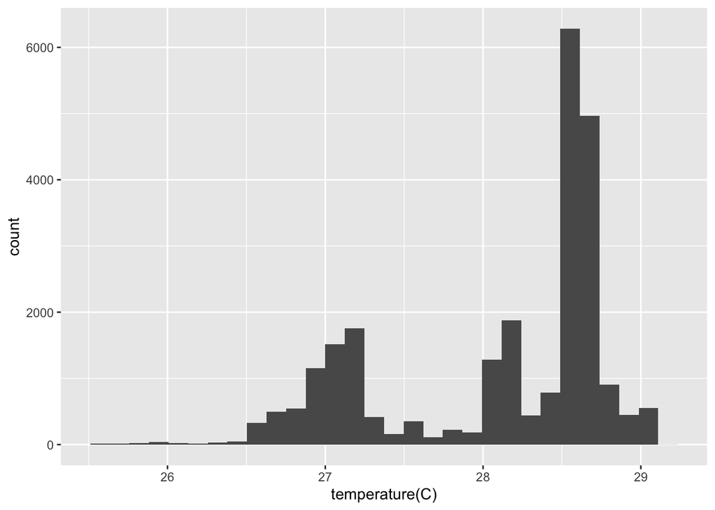

```r
#|message : false
#|eval: true
ggplot(temp_hum_flow,aes(x=`temperature(C)`)) +
  geom_histogram(bins=30)
```

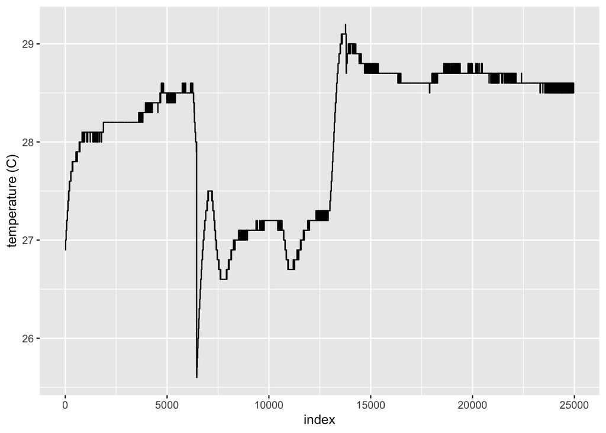

```r
ggplot(temp_hum_flow,aes(x = 1:nrow(temp_hum_flow), y=`temperature(C)`)) +
  geom_line() +
  labs(x = "index", y="temperature (C)")
```

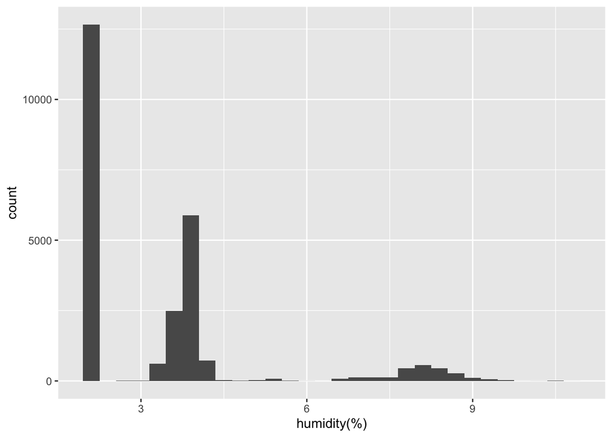

```r
ggplot(temp_hum_flow,aes(x=`humidity(%)`)) +
  geom_histogram(bins=30)
```

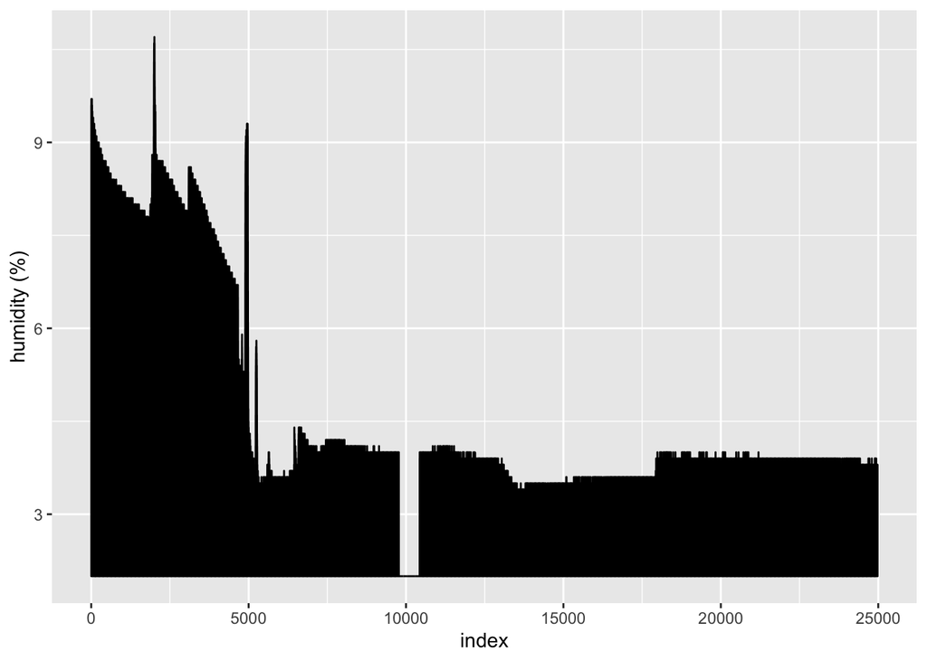

```r
ggplot(temp_hum_flow,aes(x = 1:nrow(temp_hum_flow),y=`humidity(%)`)) +
  geom_line() +
  labs(x = "index", y = "humidity (%)")
```

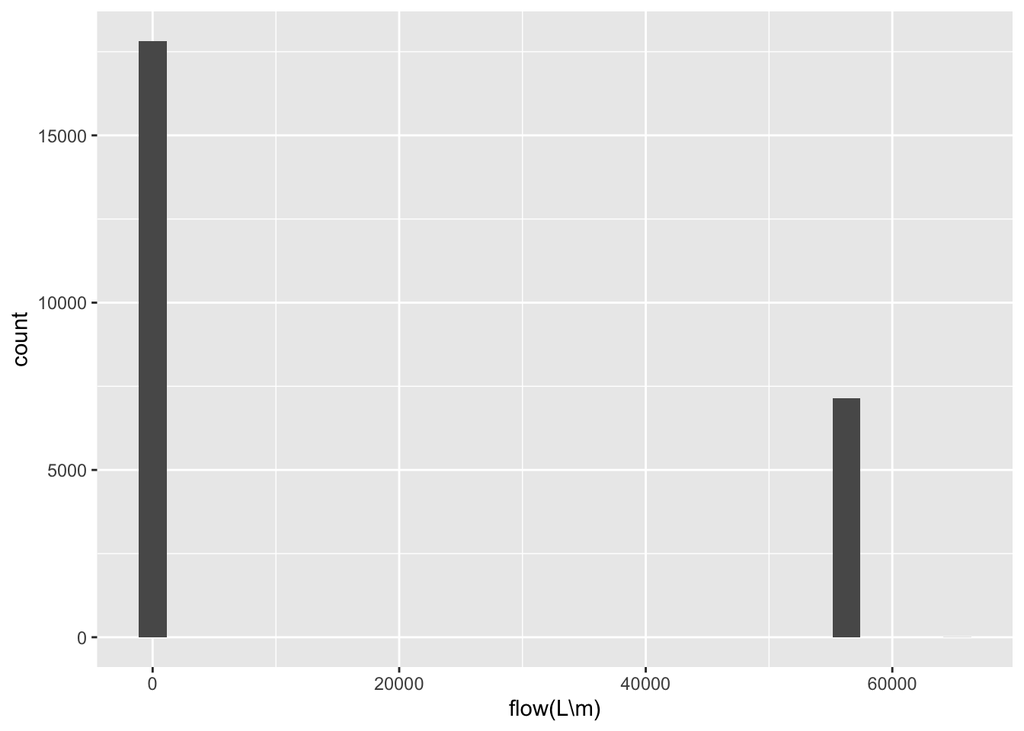

```r
ggplot(temp_hum_flow,aes(x=`flow(L\\m)`)) +
  geom_histogram(bins=30)
```